# Objective 1: Identifying Expressed Genes in GTEx Cardiomyocytes

Filtering the GTEx single-nucleus RNA-seq atlas for downstream TSS/motif analysis

Eli Brouwer

2026-08-09

## Overview

This notebook subsets the GTEx v9 single-nucleus RNA-seq atlas (8 tissues) to cardiomyocyte nuclei from heart tissue, and derives two gene sets used in downstream promoter/motif analyses:

1. **Non-zero genes** — all genes with detectable mean expression in cardiomyocytes.
2. **Top 20% genes** — the most highly expressed genes by mean expression, used as a stricter “confidently expressed” set.

Both sets are exported with HGNC symbols and, where available, matching Ensembl gene IDs.

## Paths and parameters

All input/output paths are relative to the GTEx data directory, which sits alongside this project directory. Adjust `data_dir` if the data has moved.

```r
data_dir <- "../GTEX_single_nuclear_data"

gtex_h5ad_path      <- file.path(data_dir, "GTEx_8_tissues_snRNAseq_atlas_071421.public_obs.h5ad")
gtex_metadata_path  <- file.path(data_dir, "GTEx_8_metadata.csv")
gtex_genes_path     <- file.path(data_dir, "GTEx_8_genes.csv")
gtex_matrix_dir     <- file.path(data_dir, "GTEx_8_tissues_parsed")
histogram_pdf_path  <- file.path(data_dir, "Expression_histograms.pdf")
nonzero_csv_path    <- file.path(data_dir, "GTEx_non_zeros.csv")
nonzero_ensembl_csv_path <- file.path(data_dir, "GTEx_non_zeros_ensembl.csv")
top20_csv_path      <- file.path(data_dir, "GTEx_top20%.csv")
top20_ensembl_csv_path  <- file.path(data_dir, "GTEx_top20%_ensembl.csv")
# Note: the "%" is kept in these filenames because downstream notebooks
# (e.g. Objective1_chipseeker_fimo_analysis.Rmd) read this exact filename.

top_frac_threshold <- 0.20
genes_to_annotate <- c("CPT1A", "HADHA", "HADHB", "ACADVL", "PPARG")

ensembl_host <- "https://jul2023.archive.ensembl.org"
```

## Convert the AnnData matrix to BPCells format

This chunk only needs to run once, to materialize the on-disk BPCells matrix directory used by every later chunk. It is set to `eval=FALSE` by default; flip to `TRUE` only if `gtex_matrix_dir` does not yet exist.

```r
gtex_metadata <- read.csv(gtex_metadata_path)
gtex_genes <- read.csv(gtex_genes_path)

parse_data <- open_matrix_anndata_hdf5(gtex_h5ad_path)
write_matrix_dir(mat = parse_data, dir = gtex_matrix_dir)
```

## Load the parsed matrix and metadata

```r
gtex_metadata <- read.csv(gtex_metadata_path)
gtex_mat <- open_matrix_dir(dir = gtex_matrix_dir)
gtex_mat[1:5, ]
```

```
## 5 x 209126 IterableMatrix object with class MatrixSubset
##
## Row names: FO538757.2, SAMD11 ... PLEKHN1
## Col names: CST01_TAGGCATGTAAATACG-skeletalmuscle, CST01_CCTTACGTCCGTCAAA-skeletalmuscle ... TST03_GACCAATTCCAGTATG-skin
##
## Data type: float
## Storage order: column major
##
## Queued Operations:
## 1. Load compressed matrix from directory data\GTEX_single_nuclear_data\GTEx_8_tissues_parsed
## 2. Select rows: 1, 2 ... 5 and cols: all
```

## Subset to cardiomyocytes

```r
gtex_object <- CreateSeuratObject(gtex_mat, meta.data = gtex_metadata)

cardiac_cells <- gtex_object@meta.data[
  grepl("Myocyte", gtex_object@meta.data$Broad.cell.type, ignore.case = TRUE) &
  grepl("Heart", gtex_object@meta.data$Tissue.Site.Detail, ignore.case = TRUE),
]

cardiac_cells <- cardiac_cells %>% distinct(X)

gtex_cardiomyocytes <- subset(gtex_object, cells = rownames(cardiac_cells))
```

## Mean expression per gene

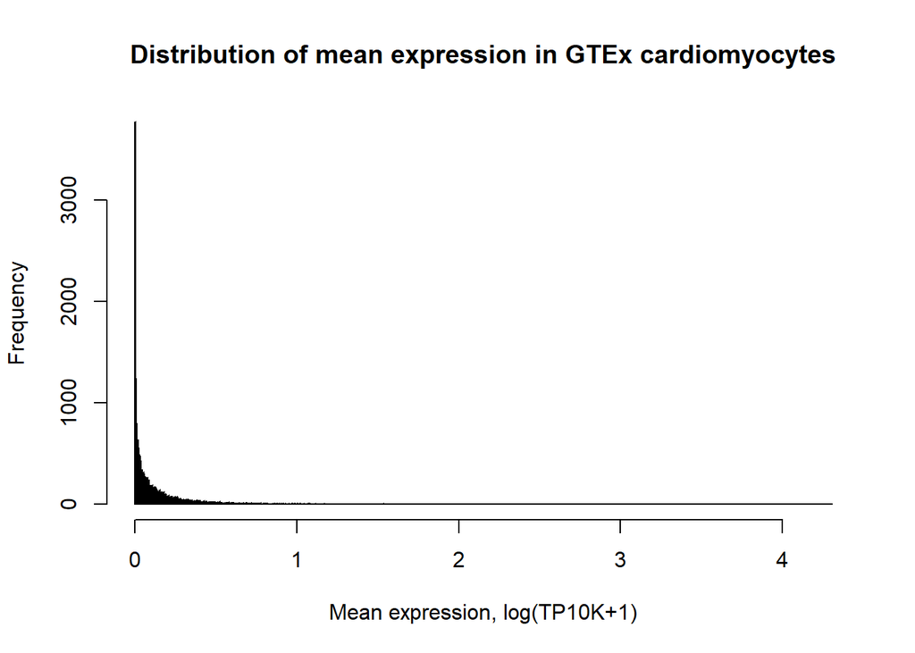

```r
expression_mat <- GetAssayData(object = gtex_cardiomyocytes, assay = "RNA", layer = "counts")
mean_expression <- rowMeans(as.matrix(expression_mat))

n_genes <- length(mean_expression)
n_zero_genes <- sum(mean_expression == 0)

hist(
  mean_expression,
  breaks = 1000,
  main = "Distribution of mean expression in GTEx cardiomyocytes",
  xlab = "Mean expression, log(TP10K+1)"
)
```

```r
summary(mean_expression)
```

```
##     Min.  1st Qu.   Median     Mean  3rd Qu.     Max.
## 0.000000 0.007382 0.047604 0.143699 0.160387 4.303884
```

```r
cat(sprintf("%.1f%% of genes have zero mean expression\n", 100 * n_zero_genes / n_genes))
```

```
## 3.6% of genes have zero mean expression
```

## Expression distribution at increasing thresholds

Histograms of the expression distribution highlighting genes retained at the non-zero, top 20%, top 10%, and top 5% cutoffs, with a panel of reference genes annotated for orientation.

```r
df_hist <- data.frame(expr = mean_expression)

gene_values <- data.frame(
  SYMBOL = genes_to_annotate,
  value = mean_expression[genes_to_annotate]
)

thresholds <- c(none = 0.00, top20 = 0.80, top10 = 0.90, top5 = 0.95)

pdf(histogram_pdf_path)

for (label in names(thresholds)) {
  cutoff <- quantile(df_hist$expr, thresholds[[label]])
  n_above <- sum(df_hist$expr > cutoff)
  cat(sprintf("Threshold '%s': %d genes above cutoff\n", label, n_above))

  p <- ggplot(df_hist, aes(x = expr)) +
    geom_histogram(aes(fill = expr < cutoff), bins = 1000) +
    scale_fill_manual(values = c("FALSE" = "grey20", "TRUE" = "red")) +
    labs(
      title = sprintf("GTEx cardiomyocyte expression, top %g%% shown", (1 - thresholds[[label]]) * 100),
      x = "Expression Values in log(TP10K+1)",
      y = "Frequency"
    ) +
    coord_cartesian(clip = "off") +
    theme_bw() +
    scale_x_continuous(limits = c(0, 2), expand = c(0, 0)) +
    scale_y_continuous(limits = c(0, 1000), expand = c(0, 0)) +
    theme(
      panel.border = element_blank(),
      panel.grid.major = element_blank(),
      panel.grid.minor = element_blank(),
      axis.line.x = element_line(color = "black"),
      axis.line.y = element_line(color = "black"),
      legend.position = "none"
    )

  for (k in seq_len(nrow(gene_values))) {
    p <- p +
      geom_vline(xintercept = gene_values$value[k], color = "blue", linetype = "dashed") +
      annotate("text",
               x = gene_values$value[k],
               y = 40 + (k %% 3) * 90,
               label = gene_values$SYMBOL[k],
               angle = 90,
               vjust = -0.5,
               size = 3,
               color = "blue")
  }

  print(p)
}
```

```
## Threshold 'none': 17057 genes above cutoff
```

```
## Threshold 'top20': 3539 genes above cutoff
```

```
## Threshold 'top10': 1770 genes above cutoff
```

```
## Threshold 'top5': 885 genes above cutoff
```

```r
dev.off()
```

## Non-zero expressed genes

```r
nonzero_genes <- mean_expression %>%
  data.frame(expression_value = .) %>%
  filter(expression_value != 0) %>%
  rownames_to_column(var = "HGNC_gene_name")
```

```r
write.csv(nonzero_genes, nonzero_csv_path, row.names = FALSE)
```

## Add Ensembl IDs to non-zero genes

```r
ensembl_nonzero <- getBM(
  mart = useEnsembl("ensembl", dataset = "hsapiens_gene_ensembl", host = ensembl_host),
  attributes = c("hgnc_symbol", "ensembl_gene_id"),
  filters = "hgnc_symbol",
  values = nonzero_genes$HGNC_gene_name
)

nonzero_genes_ensembl <- nonzero_genes %>%
  left_join(ensembl_nonzero, by = c("HGNC_gene_name" = "hgnc_symbol")) %>%
  dplyr::select(HGNC_gene_name, expression_value, ensembl_gene_id) %>%
  na.omit()
```

```r
write.csv(nonzero_genes_ensembl, nonzero_ensembl_csv_path, row.names = FALSE)
```

## Top 20% expressed genes

```r
top_x_percent <- mean_expression %>%
  data.frame(expression_value = .) %>%
  top_frac(top_frac_threshold) %>%
  rownames_to_column(var = "HGNC_gene_name")

write.csv(top_x_percent, top20_csv_path, row.names = FALSE)

ensembl_top_x <- getBM(
  mart = useEnsembl("ensembl", dataset = "hsapiens_gene_ensembl", host = ensembl_host),
  attributes = c("hgnc_symbol", "ensembl_gene_id"),
  filters = "hgnc_symbol",
  values = top_x_percent$HGNC_gene_name
)

top_x_percent_ensembl <- top_x_percent %>%
  left_join(ensembl_top_x, by = c("HGNC_gene_name" = "hgnc_symbol")) %>%
  dplyr::select(HGNC_gene_name, expression_value, ensembl_gene_id) %>%
  na.omit()

write.csv(top_x_percent_ensembl, top20_ensembl_csv_path, row.names = FALSE)
```

## Summary

```r
data.frame(
  Set = c("Non-zero genes", "Non-zero genes (with Ensembl ID)",
          sprintf("Top %g%% genes", top_frac_threshold * 100),
          sprintf("Top %g%% genes (with Ensembl ID)", top_frac_threshold * 100)),
  N_genes = c(nrow(nonzero_genes), nrow(nonzero_genes_ensembl),
              nrow(top_x_percent), nrow(top_x_percent_ensembl))
)
```

| Set | N_genes |
| --- | --- |
| Non-zero genes | 17057 |
| Non-zero genes (with Ensembl ID) | 17795 |
| Top 20% genes | 3539 |
| Top 20% genes (with Ensembl ID) | 3535 |